# Goal

### My goal is to determine how effective Air BnB is for long term stays in New York; How many options are there, what is their pricing, and to graph that data by location

```python
import pandas as pd
import numpy as np
import matplotlib as plt
import seaborn as sns

df = pd.read_csv('AB_NYC_2019.csv')
df.head()
```

|  | id | name | host_id | host_name | neighbourhood_group | neighbourhood | latitude | longitude | room_type | price | minimum_nights | number_of_reviews | last_review | reviews_per_month | calculated_host_listings_count | availability_365 |
| --- | --- | --- | --- | --- | --- | --- | --- | --- | --- | --- | --- | --- | --- | --- | --- | --- |
| 0 | 2539 | Clean & quiet apt home by the park | 2787 | John | Brooklyn | Kensington | 40.64749 | -73.97237 | Private room | 149 | 1 | 9 | 2018-10-19 | 0.21 | 6 | 365 |
| 1 | 2595 | Skylit Midtown Castle | 2845 | Jennifer | Manhattan | Midtown | 40.75362 | -73.98377 | Entire home/apt | 225 | 1 | 45 | 2019-05-21 | 0.38 | 2 | 355 |
| 2 | 3647 | THE VILLAGE OF HARLEM....NEW YORK ! | 4632 | Elisabeth | Manhattan | Harlem | 40.80902 | -73.94190 | Private room | 150 | 3 | 0 | NaN | NaN | 1 | 365 |
| 3 | 3831 | Cozy Entire Floor of Brownstone | 4869 | LisaRoxanne | Brooklyn | Clinton Hill | 40.68514 | -73.95976 | Entire home/apt | 89 | 1 | 270 | 2019-07-05 | 4.64 | 1 | 194 |
| 4 | 5022 | Entire Apt: Spacious Studio/Loft by central park | 7192 | Laura | Manhattan | East Harlem | 40.79851 | -73.94399 | Entire home/apt | 80 | 10 | 9 | 2018-11-19 | 0.10 | 1 | 0 |

idlisting: ID

name: name of the listing

host_id: host ID

host_name: name of the host

neighbourhood_group: location

neighbourhood: area

latitude: latitude coordinates

longitude: longitude coordinates

room_type: listing space type

price: price in dollars

minimum_nights: amount of nights minimum

number_of_reviews: number of reviews

last_review: latest review

reviews_per_month: number of reviews per month

calculated_host_listings_count: amount of listing per host

availability_365: number of days when listing is available for booking

```python
df.describe()
```

|  | id | host_id | latitude | longitude | price | minimum_nights | number_of_reviews | reviews_per_month | calculated_host_listings_count | availability_365 |
| --- | --- | --- | --- | --- | --- | --- | --- | --- | --- | --- |
| count | 4.889500e+04 | 4.889500e+04 | 48895.000000 | 48895.000000 | 48895.000000 | 48895.000000 | 48895.000000 | 38843.000000 | 48895.000000 | 48895.000000 |
| mean | 1.901714e+07 | 6.762001e+07 | 40.728949 | -73.952170 | 152.720687 | 7.029962 | 23.274466 | 1.373221 | 7.143982 | 112.781327 |
| std | 1.098311e+07 | 7.861097e+07 | 0.054530 | 0.046157 | 240.154170 | 20.510550 | 44.550582 | 1.680442 | 32.952519 | 131.622289 |
| min | 2.539000e+03 | 2.438000e+03 | 40.499790 | -74.244420 | 0.000000 | 1.000000 | 0.000000 | 0.010000 | 1.000000 | 0.000000 |
| 25% | 9.471945e+06 | 7.822033e+06 | 40.690100 | -73.983070 | 69.000000 | 1.000000 | 1.000000 | 0.190000 | 1.000000 | 0.000000 |
| 50% | 1.967728e+07 | 3.079382e+07 | 40.723070 | -73.955680 | 106.000000 | 3.000000 | 5.000000 | 0.720000 | 1.000000 | 45.000000 |
| 75% | 2.915218e+07 | 1.074344e+08 | 40.763115 | -73.936275 | 175.000000 | 5.000000 | 24.000000 | 2.020000 | 2.000000 | 227.000000 |
| max | 3.648724e+07 | 2.743213e+08 | 40.913060 | -73.712990 | 10000.000000 | 1250.000000 | 629.000000 | 58.500000 | 327.000000 | 365.000000 |

```python
def Stay_Type(days):
    if days == 1:
        return 'Daily'
    elif days < 7:
        return 'Multi-Daily'
    elif days == 7 :
        return 'Weekly'
    elif days < 30:
        return 'Multi-Weekly'
    elif days == 30:
        return 'Monthly'
    else:
        return 'Multi-Monthly'

df['Stay Type'] = df['minimum_nights'].apply(Stay_Type)
```

```python
df.head()
```

|  | id | name | host_id | host_name | neighbourhood_group | neighbourhood | latitude | longitude | room_type | price | minimum_nights | number_of_reviews | last_review | reviews_per_month | calculated_host_listings_count | availability_365 | Stay Type |
| --- | --- | --- | --- | --- | --- | --- | --- | --- | --- | --- | --- | --- | --- | --- | --- | --- | --- |
| 0 | 2539 | Clean & quiet apt home by the park | 2787 | John | Brooklyn | Kensington | 40.64749 | -73.97237 | Private room | 149 | 1 | 9 | 2018-10-19 | 0.21 | 6 | 365 | Daily |
| 1 | 2595 | Skylit Midtown Castle | 2845 | Jennifer | Manhattan | Midtown | 40.75362 | -73.98377 | Entire home/apt | 225 | 1 | 45 | 2019-05-21 | 0.38 | 2 | 355 | Daily |
| 2 | 3647 | THE VILLAGE OF HARLEM....NEW YORK ! | 4632 | Elisabeth | Manhattan | Harlem | 40.80902 | -73.94190 | Private room | 150 | 3 | 0 | NaN | NaN | 1 | 365 | Multi-Daily |
| 3 | 3831 | Cozy Entire Floor of Brownstone | 4869 | LisaRoxanne | Brooklyn | Clinton Hill | 40.68514 | -73.95976 | Entire home/apt | 89 | 1 | 270 | 2019-07-05 | 4.64 | 1 | 194 | Daily |
| 4 | 5022 | Entire Apt: Spacious Studio/Loft by central park | 7192 | Laura | Manhattan | East Harlem | 40.79851 | -73.94399 | Entire home/apt | 80 | 10 | 9 | 2018-11-19 | 0.10 | 1 | 0 | Multi-Weekly |

```python
df['Stay Type'].value_counts()
```

```
Multi-Daily      26784
Daily            12720
Monthly           3760
Multi-Weekly      2826
Weekly            2058
Multi-Monthly      747
Name: Stay Type, dtype: int64
```

```python
mdp = df[df['Stay Type'] == 'Multi-Daily']['price'].value_counts()
mdp.describe()
```

```
count     527.000000
mean       50.823529
std       135.281657
min         1.000000
25%         2.000000
50%         7.000000
75%        31.500000
max      1212.000000
Name: price, dtype: float64
```

```python
dp = df[df['Stay Type'] == 'Daily']['price'].value_counts()
dp.describe()
```

```
count    443.000000
mean      28.713318
std       77.294386
min        1.000000
25%        1.000000
50%        4.000000
75%       18.000000
max      653.000000
Name: price, dtype: float64
```

```python
mwp = df[df['Stay Type'] == 'Multi-Weekly']['price'].value_counts()
mwp.describe()
```

```
count    279.000000
mean      10.129032
std       18.585923
min        1.000000
25%        2.000000
50%        4.000000
75%        8.500000
max      120.000000
Name: price, dtype: float64
```

```python
wp = df[df['Stay Type'] == 'Weekly']['price'].value_counts()
wp.describe()
```

```
count    233.000000
mean       8.832618
std       15.781983
min        1.000000
25%        1.000000
50%        3.000000
75%        7.000000
max      103.000000
Name: price, dtype: float64
```

```python
mmp = df[df['Stay Type'] == 'Multi-Monthly']['price'].value_counts()
mmp.describe()
```

```
count    195.000000
mean       3.830769
std        5.464702
min        1.000000
25%        1.000000
50%        2.000000
75%        4.000000
max       33.000000
Name: price, dtype: float64
```

```python
mp = df[df['Stay Type'] == 'Monthly']['price'].sort_values()
mp.describe()
```

```
count     3760.000000
mean       182.563564
std        368.586676
min          0.000000
25%         70.000000
50%        135.000000
75%        200.000000
max      10000.000000
Name: price, dtype: float64
```

```
Stay Type
Daily            AxesSubplot(0.125,0.125;0.775x0.755)
Monthly          AxesSubplot(0.125,0.125;0.775x0.755)
Multi-Daily      AxesSubplot(0.125,0.125;0.775x0.755)
Multi-Monthly    AxesSubplot(0.125,0.125;0.775x0.755)
Multi-Weekly     AxesSubplot(0.125,0.125;0.775x0.755)
Weekly           AxesSubplot(0.125,0.125;0.775x0.755)
Name: price, dtype: object
```

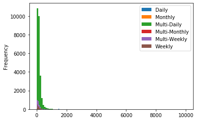

```python
df.groupby('Stay Type')['price'].plot.hist(bins=100, legend='brief')
```

```
Stay Type
Daily            AxesSubplot(0.125,0.125;0.775x0.755)
Monthly          AxesSubplot(0.125,0.125;0.775x0.755)
Multi-Daily      AxesSubplot(0.125,0.125;0.775x0.755)
Multi-Monthly    AxesSubplot(0.125,0.125;0.775x0.755)
Multi-Weekly     AxesSubplot(0.125,0.125;0.775x0.755)
Weekly           AxesSubplot(0.125,0.125;0.775x0.755)
Name: price, dtype: object
```

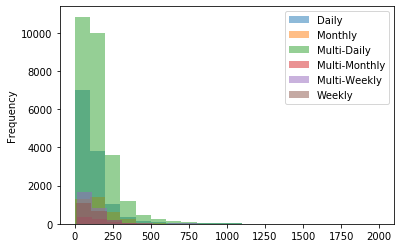

```python
df2.groupby('Stay Type')['price'].plot.hist(bins=20, legend='brief',  alpha=0.5)
```

```python
df['neighbourhood_group'].value_counts()
```

```
Manhattan        21661
Brooklyn         20104
Queens            5666
Bronx             1091
Staten Island      373
Name: neighbourhood_group, dtype: int64
```

```python
df.groupby('neighbourhood_group')['Stay Type'].value_counts()
```

```
neighbourhood_group  Stay Type
Bronx                Multi-Daily        635
                     Daily              362
                     Weekly              30
                     Multi-Weekly        26
                     Monthly             25
                     Multi-Monthly       13
Brooklyn             Multi-Daily      12053
                     Daily             4650
                     Multi-Weekly      1206
                     Monthly           1015
                     Weekly             927
                     Multi-Monthly      253
Manhattan            Multi-Daily      11176
                     Daily             5418
                     Monthly           2399
                     Multi-Weekly      1357
                     Weekly             889
                     Multi-Monthly      422
Queens               Multi-Daily       2694
                     Daily             2178
                     Monthly            306
                     Multi-Weekly       230
                     Weekly             203
                     Multi-Monthly       55
Staten Island        Multi-Daily        226
                     Daily              112
                     Monthly             15
                     Weekly               9
                     Multi-Weekly         7
                     Multi-Monthly        4
Name: Stay Type, dtype: int64
```

```python
bronx = df[df['neighbourhood_group'] == 'Bronx']
bronx.head()
```

|  | id | name | host_id | host_name | neighbourhood_group | neighbourhood | latitude | longitude | room_type | price | minimum_nights | number_of_reviews | last_review | reviews_per_month | calculated_host_listings_count | availability_365 | Stay Type |
| --- | --- | --- | --- | --- | --- | --- | --- | --- | --- | --- | --- | --- | --- | --- | --- | --- | --- |
| 171 | 44096 | Room with a View | 190409 | Waundell | Bronx | Highbridge | 40.83232 | -73.93184 | Private room | 40 | 1 | 219 | 2019-07-04 | 2.04 | 3 | 353 | Daily |
| 207 | 54626 | Cozy bedroom by Yankee Stadium | 190409 | Waundell | Bronx | Highbridge | 40.83075 | -73.93058 | Private room | 45 | 1 | 138 | 2019-06-30 | 1.45 | 3 | 323 | Daily |
| 260 | 63588 | LL3 | 295128 | Carol Gloria | Bronx | Clason Point | 40.81309 | -73.85514 | Private room | 90 | 2 | 0 | NaN | NaN | 7 | 349 | Multi-Daily |
| 261 | 63610 | DOMINIQUE'S NY mini efficiency* wifi*metro*quiet | 310670 | Vie | Bronx | Eastchester | 40.88057 | -73.83572 | Entire home/apt | 105 | 2 | 38 | 2019-06-27 | 0.50 | 13 | 365 | Multi-Daily |
| 309 | 71812 | Condo Apartment with laundry in unit | 369015 | Thai | Bronx | Kingsbridge | 40.87207 | -73.90193 | Entire home/apt | 90 | 30 | 4 | 2019-01-02 | 0.35 | 2 | 346 | Monthly |

```
Stay Type
Daily            AxesSubplot(0.125,0.125;0.775x0.755)
Monthly          AxesSubplot(0.125,0.125;0.775x0.755)
Multi-Daily      AxesSubplot(0.125,0.125;0.775x0.755)
Multi-Monthly    AxesSubplot(0.125,0.125;0.775x0.755)
Multi-Weekly     AxesSubplot(0.125,0.125;0.775x0.755)
Weekly           AxesSubplot(0.125,0.125;0.775x0.755)
Name: price, dtype: object
```

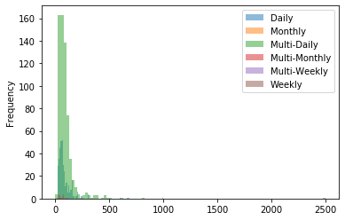

```python
bronx.groupby('Stay Type')['price'].plot.hist(bins=100, legend='brief', alpha=0.5)
```

```python
manhat = df[df['neighbourhood_group'] == 'Manhattan']
manhat.head()
```

|  | id | name | host_id | host_name | neighbourhood_group | neighbourhood | latitude | longitude | room_type | price | minimum_nights | number_of_reviews | last_review | reviews_per_month | calculated_host_listings_count | availability_365 | Stay Type |
| --- | --- | --- | --- | --- | --- | --- | --- | --- | --- | --- | --- | --- | --- | --- | --- | --- | --- |
| 1 | 2595 | Skylit Midtown Castle | 2845 | Jennifer | Manhattan | Midtown | 40.75362 | -73.98377 | Entire home/apt | 225 | 1 | 45 | 2019-05-21 | 0.38 | 2 | 355 | Daily |
| 2 | 3647 | THE VILLAGE OF HARLEM....NEW YORK ! | 4632 | Elisabeth | Manhattan | Harlem | 40.80902 | -73.94190 | Private room | 150 | 3 | 0 | NaN | NaN | 1 | 365 | Multi-Daily |
| 4 | 5022 | Entire Apt: Spacious Studio/Loft by central park | 7192 | Laura | Manhattan | East Harlem | 40.79851 | -73.94399 | Entire home/apt | 80 | 10 | 9 | 2018-11-19 | 0.10 | 1 | 0 | Multi-Weekly |
| 5 | 5099 | Large Cozy 1 BR Apartment In Midtown East | 7322 | Chris | Manhattan | Murray Hill | 40.74767 | -73.97500 | Entire home/apt | 200 | 3 | 74 | 2019-06-22 | 0.59 | 1 | 129 | Multi-Daily |
| 7 | 5178 | Large Furnished Room Near B'way | 8967 | Shunichi | Manhattan | Hell's Kitchen | 40.76489 | -73.98493 | Private room | 79 | 2 | 430 | 2019-06-24 | 3.47 | 1 | 220 | Multi-Daily |

```
Stay Type
Daily            AxesSubplot(0.125,0.125;0.775x0.755)
Monthly          AxesSubplot(0.125,0.125;0.775x0.755)
Multi-Daily      AxesSubplot(0.125,0.125;0.775x0.755)
Multi-Monthly    AxesSubplot(0.125,0.125;0.775x0.755)
Multi-Weekly     AxesSubplot(0.125,0.125;0.775x0.755)
Weekly           AxesSubplot(0.125,0.125;0.775x0.755)
Name: price, dtype: object
```

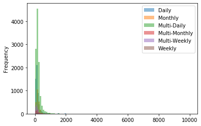

```python
manhat.groupby('Stay Type')['price'].plot.hist(bins=100, legend='brief',  alpha=0.5)
```

```python
brook = df[df['neighbourhood_group'] == 'Brooklyn']
brook.head()
```

|  | id | name | host_id | host_name | neighbourhood_group | neighbourhood | latitude | longitude | room_type | price | minimum_nights | number_of_reviews | last_review | reviews_per_month | calculated_host_listings_count | availability_365 | Stay Type |
| --- | --- | --- | --- | --- | --- | --- | --- | --- | --- | --- | --- | --- | --- | --- | --- | --- | --- |
| 0 | 2539 | Clean & quiet apt home by the park | 2787 | John | Brooklyn | Kensington | 40.64749 | -73.97237 | Private room | 149 | 1 | 9 | 2018-10-19 | 0.21 | 6 | 365 | Daily |
| 3 | 3831 | Cozy Entire Floor of Brownstone | 4869 | LisaRoxanne | Brooklyn | Clinton Hill | 40.68514 | -73.95976 | Entire home/apt | 89 | 1 | 270 | 2019-07-05 | 4.64 | 1 | 194 | Daily |
| 6 | 5121 | BlissArtsSpace! | 7356 | Garon | Brooklyn | Bedford-Stuyvesant | 40.68688 | -73.95596 | Private room | 60 | 45 | 49 | 2017-10-05 | 0.40 | 1 | 0 | Multi-Monthly |
| 12 | 5803 | Lovely Room 1, Garden, Best Area, Legal rental | 9744 | Laurie | Brooklyn | South Slope | 40.66829 | -73.98779 | Private room | 89 | 4 | 167 | 2019-06-24 | 1.34 | 3 | 314 | Multi-Daily |
| 15 | 6848 | Only 2 stops to Manhattan studio | 15991 | Allen & Irina | Brooklyn | Williamsburg | 40.70837 | -73.95352 | Entire home/apt | 140 | 2 | 148 | 2019-06-29 | 1.20 | 1 | 46 | Multi-Daily |

```
Stay Type
Daily            AxesSubplot(0.125,0.125;0.775x0.755)
Monthly          AxesSubplot(0.125,0.125;0.775x0.755)
Multi-Daily      AxesSubplot(0.125,0.125;0.775x0.755)
Multi-Monthly    AxesSubplot(0.125,0.125;0.775x0.755)
Multi-Weekly     AxesSubplot(0.125,0.125;0.775x0.755)
Weekly           AxesSubplot(0.125,0.125;0.775x0.755)
Name: price, dtype: object
```

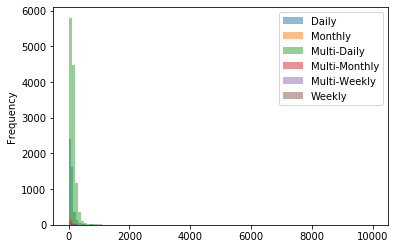

```python
brook.groupby('Stay Type')['price'].plot.hist(bins=100, legend='brief',  alpha=0.5)
```

```python
queen = df[df['neighbourhood_group'] == 'Queens']
queen.head()
```

|  | id | name | host_id | host_name | neighbourhood_group | neighbourhood | latitude | longitude | room_type | price | minimum_nights | number_of_reviews | last_review | reviews_per_month | calculated_host_listings_count | availability_365 | Stay Type |
| --- | --- | --- | --- | --- | --- | --- | --- | --- | --- | --- | --- | --- | --- | --- | --- | --- | --- |
| 46 | 12937 | 1 Stop fr. Manhattan! Private Suite,Landmark B... | 50124 | Orestes | Queens | Long Island City | 40.74771 | -73.94740 | Private room | 130 | 3 | 248 | 2019-07-01 | 2.25 | 1 | 215 | Multi-Daily |
| 77 | 18198 | Little King of Queens | 70091 | Justin | Queens | Woodside | 40.75038 | -73.90334 | Private room | 70 | 30 | 25 | 2019-05-31 | 0.22 | 1 | 324 | Monthly |
| 143 | 32363 | Fully Furnished Basement Apartment | 140025 | Fredah | Queens | Flushing | 40.74028 | -73.83168 | Private room | 140 | 2 | 1 | 2011-09-19 | 0.01 | 1 | 1 | Multi-Daily |
| 161 | 39593 | A room w/ a Manhattan view, longer stay | 110506 | Myung | Queens | Sunnyside | 40.74559 | -73.92313 | Private room | 79 | 30 | 28 | 2019-04-12 | 0.26 | 1 | 126 | Monthly |
| 181 | 45910 | Beautiful Queens Brownstone! - 5BR | 204539 | Mark | Queens | Ridgewood | 40.70382 | -73.89797 | Entire home/apt | 350 | 8 | 10 | 2019-05-12 | 0.11 | 5 | 365 | Multi-Weekly |

```
Stay Type
Daily            AxesSubplot(0.125,0.125;0.775x0.755)
Monthly          AxesSubplot(0.125,0.125;0.775x0.755)
Multi-Daily      AxesSubplot(0.125,0.125;0.775x0.755)
Multi-Monthly    AxesSubplot(0.125,0.125;0.775x0.755)
Multi-Weekly     AxesSubplot(0.125,0.125;0.775x0.755)
Weekly           AxesSubplot(0.125,0.125;0.775x0.755)
Name: price, dtype: object
```

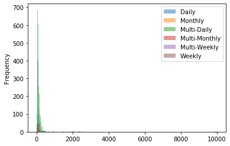

```python
queen.groupby('Stay Type')['price'].plot.hist(bins=100, legend='brief',  alpha=0.5)
```

```python
staten = df[df['neighbourhood_group'] == 'Staten Island']
staten.head()
```

|  | id | name | host_id | host_name | neighbourhood_group | neighbourhood | latitude | longitude | room_type | price | minimum_nights | number_of_reviews | last_review | reviews_per_month | calculated_host_listings_count | availability_365 | Stay Type |
| --- | --- | --- | --- | --- | --- | --- | --- | --- | --- | --- | --- | --- | --- | --- | --- | --- | --- |
| 169 | 42882 | New York room with a view | 185978 | Newyorkroomwithaview | Staten Island | St. George | 40.64524 | -74.08088 | Private room | 70 | 2 | 166 | 2019-06-13 | 1.66 | 1 | 312 | Multi-Daily |
| 249 | 62452 | A SpeciaL!! Private Room in NY | 303939 | Lissette | Staten Island | Tompkinsville | 40.63536 | -74.08537 | Private room | 36 | 2 | 193 | 2019-06-25 | 1.85 | 6 | 360 | Multi-Daily |
| 250 | 62461 | B NYC Staten Alternative... | 303939 | Lissette | Staten Island | Tompkinsville | 40.63627 | -74.08543 | Private room | 37 | 2 | 147 | 2019-06-10 | 1.44 | 6 | 0 | Multi-Daily |
| 251 | 62787 | C Private Room By The Ferry | 303939 | Lissette | Staten Island | Tompkinsville | 40.63518 | -74.08546 | Private room | 37 | 2 | 177 | 2019-07-02 | 1.71 | 6 | 320 | Multi-Daily |
| 256 | 63320 | D Private Che@p Room 2 Explore NYC | 303939 | Lissette | Staten Island | Tompkinsville | 40.63481 | -74.08519 | Private room | 36 | 2 | 333 | 2019-07-02 | 3.19 | 6 | 340 | Multi-Daily |

```
Stay Type
Daily            AxesSubplot(0.125,0.125;0.775x0.755)
Monthly          AxesSubplot(0.125,0.125;0.775x0.755)
Multi-Daily      AxesSubplot(0.125,0.125;0.775x0.755)
Multi-Monthly    AxesSubplot(0.125,0.125;0.775x0.755)
Multi-Weekly     AxesSubplot(0.125,0.125;0.775x0.755)
Weekly           AxesSubplot(0.125,0.125;0.775x0.755)
Name: price, dtype: object
```

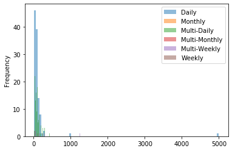

```python
staten.groupby('Stay Type')['price'].plot.hist(bins=100, legend='brief',  alpha=0.5)
```

```python
def find_remove_outlier_iqr(data_sample):
    # calculate interquartile range
    q25, q75 = np.percentile(data_sample, 25), np.percentile(data_sample, 75)
    iqr = q75 - q25
    print(q75, q25)
    print(iqr)
    # calculate the outlier cutoff
    cut_off = iqr * 1.5
    lower, upper = q25 - cut_off, q75 + cut_off
    # identify outliers
    outliers = [x for x in data_sample if x < lower or x > upper]
    # remove outliers
    outliers_removed = [x for x in data_sample if x > lower and x < upper]
    return outliers

find_remove_outlier_iqr(df['price'])
```

```
175.0 69.0
106.0
```

[output not shown]

[output cut: 946 more lines]

[output not shown]

```python
priNoOut=df[df['price'] < (175+(1.5*106))]
```

```python
priNoOut
```

|  | id | name | host_id | host_name | neighbourhood_group | neighbourhood | latitude | longitude | room_type | price | minimum_nights | number_of_reviews | last_review | reviews_per_month | calculated_host_listings_count | availability_365 | Stay Type |
| --- | --- | --- | --- | --- | --- | --- | --- | --- | --- | --- | --- | --- | --- | --- | --- | --- | --- |
| 0 | 2539 | Clean & quiet apt home by the park | 2787 | John | Brooklyn | Kensington | 40.64749 | -73.97237 | Private room | 149 | 1 | 9 | 2018-10-19 | 0.21 | 6 | 365 | Daily |
| 1 | 2595 | Skylit Midtown Castle | 2845 | Jennifer | Manhattan | Midtown | 40.75362 | -73.98377 | Entire home/apt | 225 | 1 | 45 | 2019-05-21 | 0.38 | 2 | 355 | Daily |
| 2 | 3647 | THE VILLAGE OF HARLEM....NEW YORK ! | 4632 | Elisabeth | Manhattan | Harlem | 40.80902 | -73.94190 | Private room | 150 | 3 | 0 | NaN | NaN | 1 | 365 | Multi-Daily |
| 3 | 3831 | Cozy Entire Floor of Brownstone | 4869 | LisaRoxanne | Brooklyn | Clinton Hill | 40.68514 | -73.95976 | Entire home/apt | 89 | 1 | 270 | 2019-07-05 | 4.64 | 1 | 194 | Daily |
| 4 | 5022 | Entire Apt: Spacious Studio/Loft by central park | 7192 | Laura | Manhattan | East Harlem | 40.79851 | -73.94399 | Entire home/apt | 80 | 10 | 9 | 2018-11-19 | 0.10 | 1 | 0 | Multi-Weekly |
| ... | ... | ... | ... | ... | ... | ... | ... | ... | ... | ... | ... | ... | ... | ... | ... | ... | ... |
| 48890 | 36484665 | Charming one bedroom - newly renovated rowhouse | 8232441 | Sabrina | Brooklyn | Bedford-Stuyvesant | 40.67853 | -73.94995 | Private room | 70 | 2 | 0 | NaN | NaN | 2 | 9 | Multi-Daily |
| 48891 | 36485057 | Affordable room in Bushwick/East Williamsburg | 6570630 | Marisol | Brooklyn | Bushwick | 40.70184 | -73.93317 | Private room | 40 | 4 | 0 | NaN | NaN | 2 | 36 | Multi-Daily |
| 48892 | 36485431 | Sunny Studio at Historical Neighborhood | 23492952 | Ilgar & Aysel | Manhattan | Harlem | 40.81475 | -73.94867 | Entire home/apt | 115 | 10 | 0 | NaN | NaN | 1 | 27 | Multi-Weekly |
| 48893 | 36485609 | 43rd St. Time Square-cozy single bed | 30985759 | Taz | Manhattan | Hell's Kitchen | 40.75751 | -73.99112 | Shared room | 55 | 1 | 0 | NaN | NaN | 6 | 2 | Daily |
| 48894 | 36487245 | Trendy duplex in the very heart of Hell's Kitchen | 68119814 | Christophe | Manhattan | Hell's Kitchen | 40.76404 | -73.98933 | Private room | 90 | 7 | 0 | NaN | NaN | 1 | 23 | Weekly |

45918 rows × 17 columns

```
Stay Type
Daily            AxesSubplot(0.125,0.125;0.775x0.755)
Monthly          AxesSubplot(0.125,0.125;0.775x0.755)
Multi-Daily      AxesSubplot(0.125,0.125;0.775x0.755)
Multi-Monthly    AxesSubplot(0.125,0.125;0.775x0.755)
Multi-Weekly     AxesSubplot(0.125,0.125;0.775x0.755)
Weekly           AxesSubplot(0.125,0.125;0.775x0.755)
Name: price, dtype: object
```

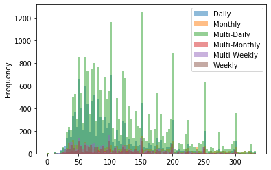

```python
priNoOut.groupby('Stay Type')['price'].plot.hist(bins=100, legend='brief', alpha=0.5)
```

```python
queenO = priNoOut[priNoOut['neighbourhood_group'] == 'Queens']
queenO.head()
```

|  | id | name | host_id | host_name | neighbourhood_group | neighbourhood | latitude | longitude | room_type | price | minimum_nights | number_of_reviews | last_review | reviews_per_month | calculated_host_listings_count | availability_365 | Stay Type |
| --- | --- | --- | --- | --- | --- | --- | --- | --- | --- | --- | --- | --- | --- | --- | --- | --- | --- |
| 46 | 12937 | 1 Stop fr. Manhattan! Private Suite,Landmark B... | 50124 | Orestes | Queens | Long Island City | 40.74771 | -73.94740 | Private room | 130 | 3 | 248 | 2019-07-01 | 2.25 | 1 | 215 | Multi-Daily |
| 77 | 18198 | Little King of Queens | 70091 | Justin | Queens | Woodside | 40.75038 | -73.90334 | Private room | 70 | 30 | 25 | 2019-05-31 | 0.22 | 1 | 324 | Monthly |
| 143 | 32363 | Fully Furnished Basement Apartment | 140025 | Fredah | Queens | Flushing | 40.74028 | -73.83168 | Private room | 140 | 2 | 1 | 2011-09-19 | 0.01 | 1 | 1 | Multi-Daily |
| 161 | 39593 | A room w/ a Manhattan view, longer stay | 110506 | Myung | Queens | Sunnyside | 40.74559 | -73.92313 | Private room | 79 | 30 | 28 | 2019-04-12 | 0.26 | 1 | 126 | Monthly |
| 196 | 51850 | ( F) Excellent/Pvt Rm | 27848 | Jullett | Queens | Jamaica | 40.67252 | -73.76597 | Private room | 55 | 2 | 52 | 2019-05-20 | 0.49 | 2 | 365 | Multi-Daily |

```python
queenO.describe()
```

|  | id | host_id | latitude | longitude | price | minimum_nights | number_of_reviews | reviews_per_month | calculated_host_listings_count | availability_365 |
| --- | --- | --- | --- | --- | --- | --- | --- | --- | --- | --- |
| count | 5.567000e+03 | 5.567000e+03 | 5567.000000 | 5567.000000 | 5567.000000 | 5567.000000 | 5567.000000 | 4514.000000 | 5567.000000 | 5567.000000 |
| mean | 2.174978e+07 | 9.614604e+07 | 40.731660 | -73.872964 | 88.904437 | 5.072391 | 27.971798 | 1.951083 | 4.094665 | 143.019041 |
| std | 1.036095e+07 | 8.425829e+07 | 0.040024 | 0.056804 | 53.536041 | 13.462033 | 52.256180 | 2.220208 | 12.550016 | 135.071371 |
| min | 1.293700e+04 | 3.211000e+03 | 40.565460 | -73.959270 | 10.000000 | 1.000000 | 0.000000 | 0.010000 | 1.000000 | 0.000000 |
| 25% | 1.398078e+07 | 2.119394e+07 | 40.707410 | -73.917390 | 50.000000 | 1.000000 | 1.000000 | 0.370000 | 1.000000 | 1.000000 |
| 50% | 2.256236e+07 | 6.826777e+07 | 40.744710 | -73.895070 | 74.000000 | 2.000000 | 7.000000 | 1.220000 | 1.000000 | 95.000000 |
| 75% | 3.074678e+07 | 1.580872e+08 | 40.759815 | -73.830115 | 108.000000 | 3.000000 | 32.000000 | 2.800000 | 3.000000 | 283.000000 |
| max | 3.648436e+07 | 2.742256e+08 | 40.795110 | -73.712990 | 325.000000 | 500.000000 | 629.000000 | 20.940000 | 103.000000 | 365.000000 |

```
Stay Type
Daily            AxesSubplot(0.125,0.125;0.775x0.755)
Monthly          AxesSubplot(0.125,0.125;0.775x0.755)
Multi-Daily      AxesSubplot(0.125,0.125;0.775x0.755)
Multi-Monthly    AxesSubplot(0.125,0.125;0.775x0.755)
Multi-Weekly     AxesSubplot(0.125,0.125;0.775x0.755)
Weekly           AxesSubplot(0.125,0.125;0.775x0.755)
Name: price, dtype: object
```

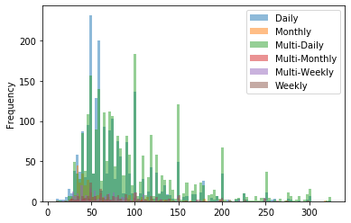

```python
queenO.groupby('Stay Type')['price'].plot.hist(bins=100, legend='brief',  alpha=0.5)
```

```
Stay Type
Daily            AxesSubplot(0.125,0.125;0.775x0.755)
Monthly          AxesSubplot(0.125,0.125;0.775x0.755)
Multi-Daily      AxesSubplot(0.125,0.125;0.775x0.755)
Multi-Monthly    AxesSubplot(0.125,0.125;0.775x0.755)
Multi-Weekly     AxesSubplot(0.125,0.125;0.775x0.755)
Weekly           AxesSubplot(0.125,0.125;0.775x0.755)
Name: price, dtype: object
```

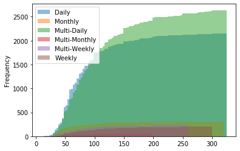

```python
queenO.groupby('Stay Type')['price'].plot.hist(bins=100, cumulative=True, legend='brief',  alpha=0.5)
```

```python
manhatO = priNoOut[priNoOut['neighbourhood_group'] == 'Manhattan']
manhatO.head()
```

|  | id | name | host_id | host_name | neighbourhood_group | neighbourhood | latitude | longitude | room_type | price | minimum_nights | number_of_reviews | last_review | reviews_per_month | calculated_host_listings_count | availability_365 | Stay Type |
| --- | --- | --- | --- | --- | --- | --- | --- | --- | --- | --- | --- | --- | --- | --- | --- | --- | --- |
| 1 | 2595 | Skylit Midtown Castle | 2845 | Jennifer | Manhattan | Midtown | 40.75362 | -73.98377 | Entire home/apt | 225 | 1 | 45 | 2019-05-21 | 0.38 | 2 | 355 | Daily |
| 2 | 3647 | THE VILLAGE OF HARLEM....NEW YORK ! | 4632 | Elisabeth | Manhattan | Harlem | 40.80902 | -73.94190 | Private room | 150 | 3 | 0 | NaN | NaN | 1 | 365 | Multi-Daily |
| 4 | 5022 | Entire Apt: Spacious Studio/Loft by central park | 7192 | Laura | Manhattan | East Harlem | 40.79851 | -73.94399 | Entire home/apt | 80 | 10 | 9 | 2018-11-19 | 0.10 | 1 | 0 | Multi-Weekly |
| 5 | 5099 | Large Cozy 1 BR Apartment In Midtown East | 7322 | Chris | Manhattan | Murray Hill | 40.74767 | -73.97500 | Entire home/apt | 200 | 3 | 74 | 2019-06-22 | 0.59 | 1 | 129 | Multi-Daily |
| 7 | 5178 | Large Furnished Room Near B'way | 8967 | Shunichi | Manhattan | Hell's Kitchen | 40.76489 | -73.98493 | Private room | 79 | 2 | 430 | 2019-06-24 | 3.47 | 1 | 220 | Multi-Daily |

```python
manhatO.describe()
```

|  | id | host_id | latitude | longitude | price | minimum_nights | number_of_reviews | reviews_per_month | calculated_host_listings_count | availability_365 |
| --- | --- | --- | --- | --- | --- | --- | --- | --- | --- | --- |
| count | 1.950100e+04 | 1.950100e+04 | 19501.000000 | 19501.000000 | 19501.000000 | 19501.000000 | 19501.000000 | 15277.000000 | 19501.000000 | 19501.000000 |
| mean | 1.847232e+07 | 6.490953e+07 | 40.766662 | -73.973519 | 145.904620 | 8.546331 | 21.954156 | 1.262157 | 11.969694 | 105.837701 |
| std | 1.106577e+07 | 7.720572e+07 | 0.039262 | 0.022353 | 70.417743 | 23.592936 | 43.816128 | 1.637489 | 46.149655 | 130.376836 |
| min | 2.595000e+03 | 2.845000e+03 | 40.702340 | -74.018510 | 0.000000 | 1.000000 | 0.000000 | 0.010000 | 1.000000 | 0.000000 |
| 25% | 9.043722e+06 | 8.245913e+06 | 40.732070 | -73.990850 | 90.000000 | 1.000000 | 1.000000 | 0.160000 | 1.000000 | 0.000000 |
| 50% | 1.862661e+07 | 2.987112e+07 | 40.762030 | -73.979580 | 135.000000 | 3.000000 | 5.000000 | 0.590000 | 1.000000 | 29.000000 |
| 75% | 2.891931e+07 | 9.717265e+07 | 40.798310 | -73.952570 | 199.000000 | 6.000000 | 20.000000 | 1.850000 | 2.000000 | 213.000000 |
| max | 3.648724e+07 | 2.743213e+08 | 40.876650 | -73.908550 | 333.000000 | 1250.000000 | 607.000000 | 58.500000 | 327.000000 | 365.000000 |

```
Stay Type
Daily            AxesSubplot(0.125,0.125;0.775x0.755)
Monthly          AxesSubplot(0.125,0.125;0.775x0.755)
Multi-Daily      AxesSubplot(0.125,0.125;0.775x0.755)
Multi-Monthly    AxesSubplot(0.125,0.125;0.775x0.755)
Multi-Weekly     AxesSubplot(0.125,0.125;0.775x0.755)
Weekly           AxesSubplot(0.125,0.125;0.775x0.755)
Name: price, dtype: object
```

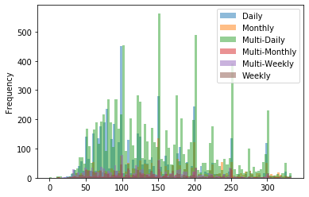

```python
manhatO.groupby('Stay Type')['price'].plot.hist(bins=100, legend='brief',  alpha=0.5)
```

```
Stay Type
Daily            AxesSubplot(0.125,0.125;0.775x0.755)
Monthly          AxesSubplot(0.125,0.125;0.775x0.755)
Multi-Daily      AxesSubplot(0.125,0.125;0.775x0.755)
Multi-Monthly    AxesSubplot(0.125,0.125;0.775x0.755)
Multi-Weekly     AxesSubplot(0.125,0.125;0.775x0.755)
Weekly           AxesSubplot(0.125,0.125;0.775x0.755)
Name: price, dtype: object
```

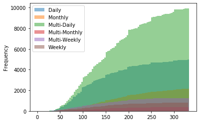

```python
manhatO.groupby('Stay Type')['price'].plot.hist(bins=100, cumulative=True, legend='brief',  alpha=0.5)
```

```python
bronxO = priNoOut[priNoOut['neighbourhood_group'] == 'Bronx']
bronxO.head()
```

|  | id | name | host_id | host_name | neighbourhood_group | neighbourhood | latitude | longitude | room_type | price | minimum_nights | number_of_reviews | last_review | reviews_per_month | calculated_host_listings_count | availability_365 | Stay Type |
| --- | --- | --- | --- | --- | --- | --- | --- | --- | --- | --- | --- | --- | --- | --- | --- | --- | --- |
| 171 | 44096 | Room with a View | 190409 | Waundell | Bronx | Highbridge | 40.83232 | -73.93184 | Private room | 40 | 1 | 219 | 2019-07-04 | 2.04 | 3 | 353 | Daily |
| 207 | 54626 | Cozy bedroom by Yankee Stadium | 190409 | Waundell | Bronx | Highbridge | 40.83075 | -73.93058 | Private room | 45 | 1 | 138 | 2019-06-30 | 1.45 | 3 | 323 | Daily |
| 260 | 63588 | LL3 | 295128 | Carol Gloria | Bronx | Clason Point | 40.81309 | -73.85514 | Private room | 90 | 2 | 0 | NaN | NaN | 7 | 349 | Multi-Daily |
| 261 | 63610 | DOMINIQUE'S NY mini efficiency* wifi*metro*quiet | 310670 | Vie | Bronx | Eastchester | 40.88057 | -73.83572 | Entire home/apt | 105 | 2 | 38 | 2019-06-27 | 0.50 | 13 | 365 | Multi-Daily |
| 309 | 71812 | Condo Apartment with laundry in unit | 369015 | Thai | Bronx | Kingsbridge | 40.87207 | -73.90193 | Entire home/apt | 90 | 30 | 4 | 2019-01-02 | 0.35 | 2 | 346 | Monthly |

```python
bronxO.describe()
```

|  | id | host_id | latitude | longitude | price | minimum_nights | number_of_reviews | reviews_per_month | calculated_host_listings_count | availability_365 |
| --- | --- | --- | --- | --- | --- | --- | --- | --- | --- | --- |
| count | 1.070000e+03 | 1.070000e+03 | 1070.000000 | 1070.000000 | 1070.000000 | 1070.000000 | 1070.000000 | 866.000000 | 1070.000000 | 1070.000000 |
| mean | 2.275312e+07 | 1.061791e+08 | 40.848208 | -73.884825 | 77.365421 | 4.598131 | 26.341121 | 1.851305 | 2.224299 | 164.564486 |
| std | 1.024594e+07 | 8.743876e+07 | 0.026683 | 0.032602 | 47.110940 | 15.779503 | 42.470201 | 1.676619 | 2.365200 | 134.972883 |
| min | 4.409600e+04 | 1.222100e+04 | 40.800110 | -73.931900 | 0.000000 | 1.000000 | 0.000000 | 0.020000 | 1.000000 | 0.000000 |
| 25% | 1.621474e+07 | 2.146033e+07 | 40.826628 | -73.911068 | 45.000000 | 1.000000 | 1.000000 | 0.490000 | 1.000000 | 36.250000 |
| 50% | 2.399778e+07 | 9.187481e+07 | 40.846205 | -73.892700 | 65.000000 | 2.000000 | 9.000000 | 1.400000 | 1.000000 | 146.000000 |
| 75% | 3.192457e+07 | 1.796772e+08 | 40.869452 | -73.858648 | 95.000000 | 3.000000 | 32.000000 | 2.817500 | 2.000000 | 312.000000 |
| max | 3.644225e+07 | 2.738773e+08 | 40.913060 | -73.781580 | 325.000000 | 365.000000 | 321.000000 | 10.340000 | 37.000000 | 365.000000 |

```
Stay Type
Daily            AxesSubplot(0.125,0.125;0.775x0.755)
Monthly          AxesSubplot(0.125,0.125;0.775x0.755)
Multi-Daily      AxesSubplot(0.125,0.125;0.775x0.755)
Multi-Monthly    AxesSubplot(0.125,0.125;0.775x0.755)
Multi-Weekly     AxesSubplot(0.125,0.125;0.775x0.755)
Weekly           AxesSubplot(0.125,0.125;0.775x0.755)
Name: price, dtype: object
```

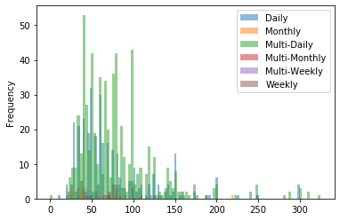

```python
bronxO.groupby('Stay Type')['price'].plot.hist(bins=100, legend='brief',  alpha=0.5)
```

```
Stay Type
Daily            AxesSubplot(0.125,0.125;0.775x0.755)
Monthly          AxesSubplot(0.125,0.125;0.775x0.755)
Multi-Daily      AxesSubplot(0.125,0.125;0.775x0.755)
Multi-Monthly    AxesSubplot(0.125,0.125;0.775x0.755)
Multi-Weekly     AxesSubplot(0.125,0.125;0.775x0.755)
Weekly           AxesSubplot(0.125,0.125;0.775x0.755)
Name: price, dtype: object
```

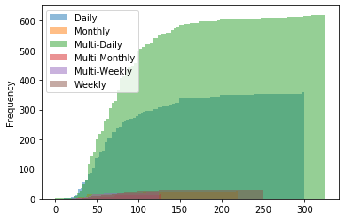

```python
bronxO.groupby('Stay Type')['price'].plot.hist(bins=100, cumulative=True, legend='brief',  alpha=0.5)
```

```python
statenO = priNoOut[priNoOut['neighbourhood_group'] == 'Staten Island']
statenO.head()
```

|  | id | name | host_id | host_name | neighbourhood_group | neighbourhood | latitude | longitude | room_type | price | minimum_nights | number_of_reviews | last_review | reviews_per_month | calculated_host_listings_count | availability_365 | Stay Type |
| --- | --- | --- | --- | --- | --- | --- | --- | --- | --- | --- | --- | --- | --- | --- | --- | --- | --- |
| 169 | 42882 | New York room with a view | 185978 | Newyorkroomwithaview | Staten Island | St. George | 40.64524 | -74.08088 | Private room | 70 | 2 | 166 | 2019-06-13 | 1.66 | 1 | 312 | Multi-Daily |
| 249 | 62452 | A SpeciaL!! Private Room in NY | 303939 | Lissette | Staten Island | Tompkinsville | 40.63536 | -74.08537 | Private room | 36 | 2 | 193 | 2019-06-25 | 1.85 | 6 | 360 | Multi-Daily |
| 250 | 62461 | B NYC Staten Alternative... | 303939 | Lissette | Staten Island | Tompkinsville | 40.63627 | -74.08543 | Private room | 37 | 2 | 147 | 2019-06-10 | 1.44 | 6 | 0 | Multi-Daily |
| 251 | 62787 | C Private Room By The Ferry | 303939 | Lissette | Staten Island | Tompkinsville | 40.63518 | -74.08546 | Private room | 37 | 2 | 177 | 2019-07-02 | 1.71 | 6 | 320 | Multi-Daily |
| 256 | 63320 | D Private Che@p Room 2 Explore NYC | 303939 | Lissette | Staten Island | Tompkinsville | 40.63481 | -74.08519 | Private room | 36 | 2 | 333 | 2019-07-02 | 3.19 | 6 | 340 | Multi-Daily |

```python
statenO.describe()
```

|  | id | host_id | latitude | longitude | price | minimum_nights | number_of_reviews | reviews_per_month | calculated_host_listings_count | availability_365 |
| --- | --- | --- | --- | --- | --- | --- | --- | --- | --- | --- |
| count | 3.650000e+02 | 3.650000e+02 | 365.000000 | 365.000000 | 365.000000 | 365.000000 | 365.000000 | 312.000000 | 365.000000 | 365.000000 |
| mean | 2.172860e+07 | 9.970187e+07 | 40.610503 | -74.105723 | 89.235616 | 4.824658 | 31.605479 | 1.884231 | 2.334247 | 199.893151 |
| std | 1.028130e+07 | 7.914363e+07 | 0.032162 | 0.035906 | 57.700147 | 19.934148 | 45.092006 | 1.684570 | 1.926694 | 131.038548 |
| min | 4.288200e+04 | 1.552300e+04 | 40.499790 | -74.244420 | 13.000000 | 1.000000 | 0.000000 | 0.020000 | 1.000000 | 0.000000 |
| 25% | 1.583357e+07 | 2.617808e+07 | 40.593850 | -74.123930 | 50.000000 | 1.000000 | 2.000000 | 0.717500 | 1.000000 | 80.000000 |
| 50% | 2.314811e+07 | 9.557054e+07 | 40.622570 | -74.089300 | 75.000000 | 2.000000 | 13.000000 | 1.410000 | 1.000000 | 219.000000 |
| 75% | 3.008296e+07 | 1.581790e+08 | 40.634740 | -74.081270 | 105.000000 | 3.000000 | 45.000000 | 2.625000 | 3.000000 | 326.000000 |
| max | 3.643834e+07 | 2.725577e+08 | 40.647790 | -74.062080 | 300.000000 | 365.000000 | 333.000000 | 10.120000 | 8.000000 | 365.000000 |

```
Stay Type
Daily            AxesSubplot(0.125,0.125;0.775x0.755)
Monthly          AxesSubplot(0.125,0.125;0.775x0.755)
Multi-Daily      AxesSubplot(0.125,0.125;0.775x0.755)
Multi-Monthly    AxesSubplot(0.125,0.125;0.775x0.755)
Multi-Weekly     AxesSubplot(0.125,0.125;0.775x0.755)
Weekly           AxesSubplot(0.125,0.125;0.775x0.755)
Name: price, dtype: object
```

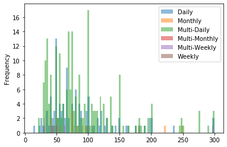

```python
statenO.groupby('Stay Type')['price'].plot.hist(bins=100, legend='brief',  alpha=0.5)
```

```
Stay Type
Daily            AxesSubplot(0.125,0.125;0.775x0.755)
Monthly          AxesSubplot(0.125,0.125;0.775x0.755)
Multi-Daily      AxesSubplot(0.125,0.125;0.775x0.755)
Multi-Monthly    AxesSubplot(0.125,0.125;0.775x0.755)
Multi-Weekly     AxesSubplot(0.125,0.125;0.775x0.755)
Weekly           AxesSubplot(0.125,0.125;0.775x0.755)
Name: price, dtype: object
```

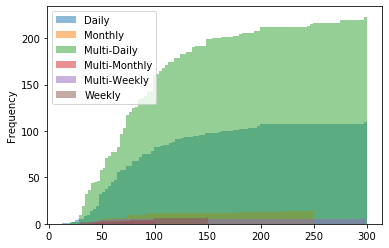

```python
statenO.groupby('Stay Type')['price'].plot.hist(bins=100, cumulative=True, legend='brief',  alpha=0.5)
```

```python
brookO = priNoOut[priNoOut['neighbourhood_group'] == 'Brooklyn']
brookO.head()
```

|  | id | name | host_id | host_name | neighbourhood_group | neighbourhood | latitude | longitude | room_type | price | minimum_nights | number_of_reviews | last_review | reviews_per_month | calculated_host_listings_count | availability_365 | Stay Type |
| --- | --- | --- | --- | --- | --- | --- | --- | --- | --- | --- | --- | --- | --- | --- | --- | --- | --- |
| 0 | 2539 | Clean & quiet apt home by the park | 2787 | John | Brooklyn | Kensington | 40.64749 | -73.97237 | Private room | 149 | 1 | 9 | 2018-10-19 | 0.21 | 6 | 365 | Daily |
| 3 | 3831 | Cozy Entire Floor of Brownstone | 4869 | LisaRoxanne | Brooklyn | Clinton Hill | 40.68514 | -73.95976 | Entire home/apt | 89 | 1 | 270 | 2019-07-05 | 4.64 | 1 | 194 | Daily |
| 6 | 5121 | BlissArtsSpace! | 7356 | Garon | Brooklyn | Bedford-Stuyvesant | 40.68688 | -73.95596 | Private room | 60 | 45 | 49 | 2017-10-05 | 0.40 | 1 | 0 | Multi-Monthly |
| 12 | 5803 | Lovely Room 1, Garden, Best Area, Legal rental | 9744 | Laurie | Brooklyn | South Slope | 40.66829 | -73.98779 | Private room | 89 | 4 | 167 | 2019-06-24 | 1.34 | 3 | 314 | Multi-Daily |
| 15 | 6848 | Only 2 stops to Manhattan studio | 15991 | Allen & Irina | Brooklyn | Williamsburg | 40.70837 | -73.95352 | Entire home/apt | 140 | 2 | 148 | 2019-06-29 | 1.20 | 1 | 46 | Multi-Daily |

```python
brookO.describe()
```

|  | id | host_id | latitude | longitude | price | minimum_nights | number_of_reviews | reviews_per_month | calculated_host_listings_count | availability_365 |
| --- | --- | --- | --- | --- | --- | --- | --- | --- | --- | --- |
| count | 1.941500e+04 | 1.941500e+04 | 19415.000000 | 19415.000000 | 19415.000000 | 19415.000000 | 19415.000000 | 15940.000000 | 19415.000000 | 19415.000000 |
| mean | 1.824182e+07 | 5.637151e+07 | 40.684853 | -73.950853 | 105.699614 | 6.021375 | 24.513830 | 1.291708 | 2.293999 | 98.500644 |
| std | 1.079492e+07 | 7.212686e+07 | 0.027441 | 0.025517 | 60.937808 | 17.193444 | 44.700108 | 1.524952 | 5.331370 | 125.429709 |
| min | 2.539000e+03 | 2.438000e+03 | 40.571150 | -74.039420 | 0.000000 | 1.000000 | 0.000000 | 0.010000 | 1.000000 | 0.000000 |
| 25% | 8.767934e+06 | 5.654072e+06 | 40.672400 | -73.963170 | 60.000000 | 2.000000 | 1.000000 | 0.180000 | 1.000000 | 0.000000 |
| 50% | 1.884251e+07 | 2.290235e+07 | 40.687500 | -73.951410 | 90.000000 | 3.000000 | 6.000000 | 0.660000 | 1.000000 | 26.000000 |
| 75% | 2.778432e+07 | 7.844135e+07 | 40.704680 | -73.935380 | 140.000000 | 5.000000 | 26.000000 | 1.992500 | 2.000000 | 185.000000 |
| max | 3.648506e+07 | 2.743076e+08 | 40.738900 | -73.856760 | 333.000000 | 999.000000 | 488.000000 | 14.000000 | 232.000000 | 365.000000 |

```
Stay Type
Daily            AxesSubplot(0.125,0.125;0.775x0.755)
Monthly          AxesSubplot(0.125,0.125;0.775x0.755)
Multi-Daily      AxesSubplot(0.125,0.125;0.775x0.755)
Multi-Monthly    AxesSubplot(0.125,0.125;0.775x0.755)
Multi-Weekly     AxesSubplot(0.125,0.125;0.775x0.755)
Weekly           AxesSubplot(0.125,0.125;0.775x0.755)
Name: price, dtype: object
```

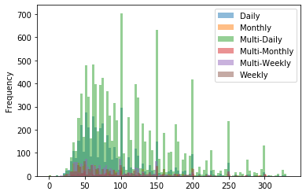

```python
brookO.groupby('Stay Type')['price'].plot.hist(bins=100, legend='brief',  alpha=0.5)
```

```
Stay Type
Daily            AxesSubplot(0.125,0.125;0.775x0.755)
Monthly          AxesSubplot(0.125,0.125;0.775x0.755)
Multi-Daily      AxesSubplot(0.125,0.125;0.775x0.755)
Multi-Monthly    AxesSubplot(0.125,0.125;0.775x0.755)
Multi-Weekly     AxesSubplot(0.125,0.125;0.775x0.755)
Weekly           AxesSubplot(0.125,0.125;0.775x0.755)
Name: price, dtype: object
```

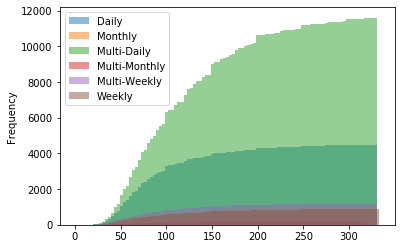

```python
brookO.groupby('Stay Type')['price'].plot.hist(bins=100, cumulative=True, legend='brief',  alpha=0.5)
```

# How I did it...

My goal in this anaylsis was to examine Air BnB's New York data from 2019, and determine, which type of stay offered the best rates, and how those rates changed based on the Neighbourhood the Air BnB was located.

I started this analysis by seperating the number of minimum days into types of stay; Each location was given a qualifier that made it easy to tell how many days the property would be bookable for. Those qualifiers were: Daily (bookable by any day), Multi-Daily (bookable by multiple day at a time), Weekly (bookable by week), Multi-Weekly (bookable by more than a week at a time), Monthly (bookable by month), Multi-Monthly (bookable by more than a month at a time). The main purpose of this split was to make the data more readable in graphing, for sort-term vs long-term properties.

Next my goal was to examine the total cost graph and how that was changed by stay-type. Following that I examined the data by neighbourhood and stay-type/price. Finally, I did some outlier checking and examined the data that fit the IQR analysis, by neighbourhood, stay type, and price.

# Why I did it...

My reasoning was to find the best stays, as it could help determine possible alternatives for long term stay for people who need to be in New York for longer than a month periods, but shorter than a year periods. Cleaning the data and sorting by price, also gives us a better understanding of how the market in New York looks year round for rental properties.

# What I found...

Through my analysis I found a few trends:

3 - Most rents are rounded numbers divisible by 5; aka most rent hover around 50, 100, 150, etc

4 - Brooklyn and Manhattan rent out the most properties, followed by queens, the bronx and staten island with the least

5 - Even after IQR analysis, those placements are still correct

6 - IQR dismisses about 3000 properties

Manhattan - One of the largest markets, with a mode of 150 and a left heavy distribution, but a significant number of right side data points. Additionally, there is not real difference between which stay type in price, most types have a similar distribution. Manhattan would be a more expensive option on average, but fair, regardless of stay.

# What I found (cont)...

Bronx - The second smallest market, with a large dip from queens in quantity, it reflects a similar trend with a left skewed distribution and little high cost rentals. It is unquie with the lowest mode of about 40, and a fairly solid distrubtion center around 50. Definitely a cheaper option though no distinguishable differences between stay type.

Staten Island - The smallest market, it does not reflect the trend of smaller equalling lower cost. with a mode of 100 and a right skewed distribution, this market has an anomoly, where it has a large quantity of cheaper options, a few median options, and quite a sizable higher cost rentals, compared to most distributions. aka there is not a huge drop off after the price increases post mode.

# Conclusion...